# 환경데이터 전처리

대구대학교 권태용

## **Importing a data in R**

- R을 이용하여 분석하기 위해선 데이터를 입력해야 하는데 그 방법이 두가지가 있다.
- c()함수와 data.frame()함수를 이용하여 R에 직접 데이터를 입력하기
- read_excel() 또는 read.csv(), read.table() 등 함수를 이용하여 외부자료 불러오기

### 데이터 프레임 생성

- R에서 자료를 처리하는 기본 구조이다.

```r
english <- c(90, 80, 60, 70) # 영어 점수 변수 생성
english
```

```
## [1] 90 80 60 70
```

```r
math <- c(50, 60, 100, 20) # 수학 점수 변수 생성
math
```

```
## [1]  50  60 100  20
```

```r
df_midterm <- data.frame(english, math)
df_midterm
```

```
##   english math
## 1      90   50
## 2      80   60
## 3      60  100
## 4      70   20
```

```r
class <- c(1, 1, 2, 2)
class
```

```
## [1] 1 1 2 2
```

```r
df_midterm <- data.frame(english, math, class)
df_midterm
```

```
##   english math class
## 1      90   50     1
## 2      80   60     1
## 3      60  100     2
## 4      70   20     2
```

```r
mean(df_midterm$english) # df_midterm의 english로 평균 산출
```

```
## [1] 75
```

```r
mean(df_midterm$math) # df_midterm의 math로 평균 산술
```

```
## [1] 57.5
```

```r
df_midterm <- data.frame(english = c(90, 80, 60, 70),
                         math = c(50, 60, 100, 20),
                         class = c(1, 1, 2, 2))
df_midterm
```

```
##   english math class
## 1      90   50     1
## 2      80   60     1
## 3      60  100     2
## 4      70   20     2
```

- Excel의 스프레드시트라고 생각하면 된다.

[output not shown]

위의 자료를 R에 입력하여 분석해보자.

- c()함수를 이용하여 문자, 숫자에 맞게 자료를 생성한다.
- 생성된 자료를 data.frame() 함수로 묶으면 된다.

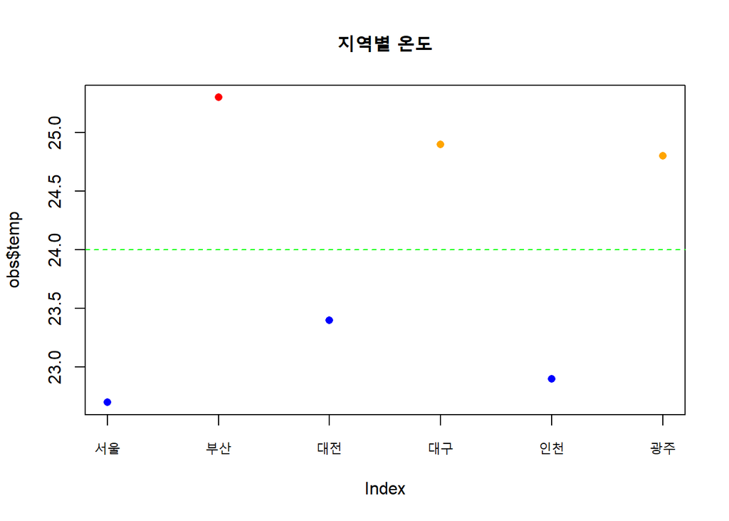

```r
stn <- c( "서울", "부산","대전","대구","인천","광주")
temp <- c(22.7,25.3,23.4,24.9,22.9,24.8)
prec <- c(0,18.5,4,10.4,0,0)
ws <- c(0.5,1.2,0.9,1.2,0.7,2.4)
rh <- c(89,97,96,97,85,84)

obs <- data.frame(stn,temp,prec,ws,rh)

obs$col <- ifelse(obs$temp>mean(obs$temp),"orange","blue")
obs[obs$temp==max(obs$temp),"col"]="red"

plot(obs$temp, col=obs$col, main="지역별 온도",pch=16, axes=F)
axis(1,at=1:6,labels=obs$stn)
axis(2)
box()
abline(h=mean(obs$temp),col="green",lty=2)
```

### 외부자료 불러오기 (excel, csv)

- 윈도우의 경우 주소를 복사하면 ↘ (back slash)가 있는데 R에서는 인식되지 않으므로 모두 /(slash)로 바꾸자.
- 파일이 불러와지지 않는 경우 인코딩 문제(글자깨짐)일 수 있다. read.csv(“경로/파일명.csv”,fileEncoding = ‘cp949’,encoding = ‘utf-8’)
- excel 파일은 library(readxl)를 불러온 후 read_excel()함수로 불러오면 된다.

```r
if(!require(readxl)) install.packages("readxl")
library(readxl)
school.data <- read_excel("C:/Users/user/Desktop/강의/r_base/r_base1/excel_exam.xlsx")
head(school.data)
```

```
## # A tibble: 6 × 5
##      id class  math english science
##   <dbl> <dbl> <dbl>   <dbl>   <dbl>
## 1     1     1    50      98      50
## 2     2     1    60      97      60
## 3     3     1    45      86      78
## 4     4     1    30      98      58
## 5     5     2    25      80      65
## 6     6     2    50      89      98
```

- csv 파일은 read.csv()파일로 불러오자.

```r
school.csv <- read.csv("C:/Users/user/Desktop/강의/r_base/r_base1/csv_exam.csv")
head(school.csv)
```

```
##   id class math english science
## 1  1     1   50      98      50
## 2  2     1   60      97      60
## 3  3     1   45      86      78
## 4  4     1   30      98      58
## 5  5     2   25      80      65
## 6  6     2   50      89      98
```

- 파일을 불러올때 기본경로를 설정할 수 있다.

```r
setwd("C:/Users/user/Desktop/강의/r_base/r_base1")
school.csv2 <- read.csv("csv_exam.csv")
head(school.csv2)
```

```
##   id class math english science
## 1  1     1   50      98      50
## 2  2     1   60      97      60
## 3  3     1   45      86      78
## 4  4     1   30      98      58
## 5  5     2   25      80      65
## 6  6     2   50      89      98
```

- window는 choose.files()함수를 통해 파일을 대화상자를 통해 선택할 수 있다.

- Ctrl + c or v 를 통한 파일 불러오기 및 저장하기

```r
data=read.csv('clipboard',sep="\t")
data

data2=read.table("clipboard",header=T)
data2

write.table(data,"clipboard",sep="\t")
```

- 저장하기

```r
head(obs)
```

```
##    stn temp prec  ws rh    col
## 1 서울 22.7  0.0 0.5 89   blue
## 2 부산 25.3 18.5 1.2 97    red
## 3 대전 23.4  4.0 0.9 96   blue
## 4 대구 24.9 10.4 1.2 97 orange
## 5 인천 22.9  0.0 0.7 85   blue
## 6 광주 24.8  0.0 2.4 84 orange
```

```r
write.csv(obs,file="C:/Users/user/Desktop/강의/r_base/r_base1/KMA.csv")

if(!require(writexl)) install.packages("writexl")
library(writexl)

write_xlsx(obs,"KMA.xlsx")
```

### Check the data after reading

- 자료를 불러왔으면 잘 불러졌는지 확인 해야한다.
- 불러온 자료를 확인하기 위한 함수로 dim(), head(), tail(), str(), View()가 있다.
- dim : 행과 열의 수 확인
- head : 자료의 앞부분 확인
- tail : 자료의 마지막 확인
- str : 자료의 구조 확인
- View : R viewer를 통해 자료 확인

```r
dim(school.data)
```

```
## [1] 20  5
```

```r
nrow(school.data)
```

```
## [1] 20
```

```r
ncol(school.data)
```

```
## [1] 5
```

```r
head(school.data)
```

```
## # A tibble: 6 × 5
##      id class  math english science
##   <dbl> <dbl> <dbl>   <dbl>   <dbl>
## 1     1     1    50      98      50
## 2     2     1    60      97      60
## 3     3     1    45      86      78
## 4     4     1    30      98      58
## 5     5     2    25      80      65
## 6     6     2    50      89      98
```

```r
head(school.data,10)
```

```
## # A tibble: 10 × 5
##       id class  math english science
##    <dbl> <dbl> <dbl>   <dbl>   <dbl>
##  1     1     1    50      98      50
##  2     2     1    60      97      60
##  3     3     1    45      86      78
##  4     4     1    30      98      58
##  5     5     2    25      80      65
##  6     6     2    50      89      98
##  7     7     2    80      90      45
##  8     8     2    90      78      25
##  9     9     3    20      98      15
## 10    10     3    50      98      45
```

```r
tail(school.data)
```

```
## # A tibble: 6 × 5
##      id class  math english science
##   <dbl> <dbl> <dbl>   <dbl>   <dbl>
## 1    15     4    75      56      78
## 2    16     4    58      98      65
## 3    17     5    65      68      98
## 4    18     5    80      78      90
## 5    19     5    89      68      87
## 6    20     5    78      83      58
```

```r
tail(school.data,10)
```

```
## # A tibble: 10 × 5
##       id class  math english science
##    <dbl> <dbl> <dbl>   <dbl>   <dbl>
##  1    11     3    65      65      65
##  2    12     3    45      85      32
##  3    13     4    46      98      65
##  4    14     4    48      87      12
##  5    15     4    75      56      78
##  6    16     4    58      98      65
##  7    17     5    65      68      98
##  8    18     5    80      78      90
##  9    19     5    89      68      87
## 10    20     5    78      83      58
```

```r
str(school.data)
```

```
## tibble [20 × 5] (S3: tbl_df/tbl/data.frame)
##  $ id     : num [1:20] 1 2 3 4 5 6 7 8 9 10 ...
##  $ class  : num [1:20] 1 1 1 1 2 2 2 2 3 3 ...
##  $ math   : num [1:20] 50 60 45 30 25 50 80 90 20 50 ...
##  $ english: num [1:20] 98 97 86 98 80 89 90 78 98 98 ...
##  $ science: num [1:20] 50 60 78 58 65 98 45 25 15 45 ...
```

```r
View(school.data) # V 대문자

mean(school.data$math)
```

```
## [1] 57.45
```

```r
mean(school.data$english)
```

```
## [1] 84.9
```

- 변수명 확인

```r
names(school.data)
```

```
## [1] "id"      "class"   "math"    "english" "science"
```

```r
colnames(school.data)
```

```
## [1] "id"      "class"   "math"    "english" "science"
```

```r
rownames(school.data)
```

```
##  [1] "1"  "2"  "3"  "4"  "5"  "6"  "7"  "8"  "9"  "10" "11" "12" "13" "14" "15"
## [16] "16" "17" "18" "19" "20"
```

```r
if(!require(dplyr)) install.packages("dplyr")
library(dplyr)

data_new <- rename(school.data, id_num = id) # id를 id_num로 수정
head(data_new)
```

```
## # A tibble: 6 × 5
##   id_num class  math english science
##    <dbl> <dbl> <dbl>   <dbl>   <dbl>
## 1      1     1    50      98      50
## 2      2     1    60      97      60
## 3      3     1    45      86      78
## 4      4     1    30      98      58
## 5      5     2    25      80      65
## 6      6     2    50      89      98
```

## **데이터 정제하기**

결측치(Missing Value) - 누락된 값, 비어있는 값 - 함수 적용 불가, 분석 결과 왜곡 - 제거 후 분석 실시

```r
df <- data.frame(sex = c("M", "F", NA, "M", "F"), score = c(5, 4, 3, 4, NA))
df
```

```
##    sex score
## 1    M     5
## 2    F     4
## 3 <NA>     3
## 4    M     4
## 5    F    NA
```

결측치 표기 : 대문자 NA

```r
is.na(df) # 결측치 확인
```

```
##        sex score
## [1,] FALSE FALSE
## [2,] FALSE FALSE
## [3,]  TRUE FALSE
## [4,] FALSE FALSE
## [5,] FALSE  TRUE
```

```r
table(is.na(df)) # 결측치 빈도 출력
```

```
##
## FALSE  TRUE
##     8     2
```

```r
mean(df$score)
```

```
## [1] NA
```

```r
sum(df$score)
```

```
## [1] NA
```

```r
df_nomiss <- df[!is.na(df$score),]
mean(df_nomiss$score)
```

```
## [1] 4
```

```r
sum(df_nomiss$score)
```

```
## [1] 16
```

```r
df_nomiss <- df[!is.na(df$score) & !is.na(df$sex),]
df_nomiss
```

```
##   sex score
## 1   M     5
## 2   F     4
## 4   M     4
```

```r
mean(df$score, na.rm = T)
```

```
## [1] 4
```

```r
sum(df$score, na.rm = T)
```

```
## [1] 16
```

```r
df[complete.cases(df),] # 결측치가 없는 관측치만
```

```
##   sex score
## 1   M     5
## 2   F     4
## 4   M     4
```

결측치 보간하기

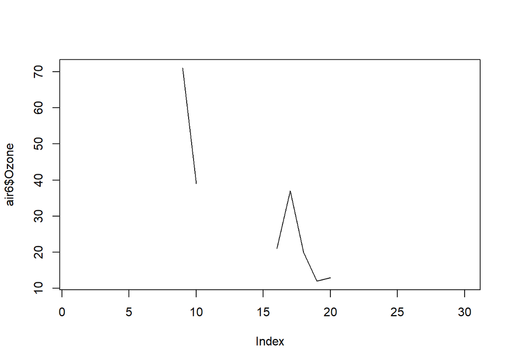

```r
air=airquality
air6=air[air$Month==6,]
plot(air6$Ozone,type="l")
```

```r
table(is.na(air6$Ozone))
```

```
##
## FALSE  TRUE
##     9    21
```

```r
if(!require(zoo)) install.packages("zoo")
library(zoo)

air6_new = air6
air6_new$Ozone
```

```
##  [1] NA NA NA NA NA NA 29 NA 71 39 NA NA 23 NA NA 21 37 20 12 13 NA NA NA NA NA
## [26] NA NA NA NA NA
```

```r
temp1 = na.approx(air6_new$Ozone,na.rm=F)
temp2 = na.locf(temp1,na.rm=F)
air6_new$Ozone = na.locf(temp2,fromLast=T)

table(is.na(air6_new$Ozone))
```

```
##
## FALSE
##    30
```

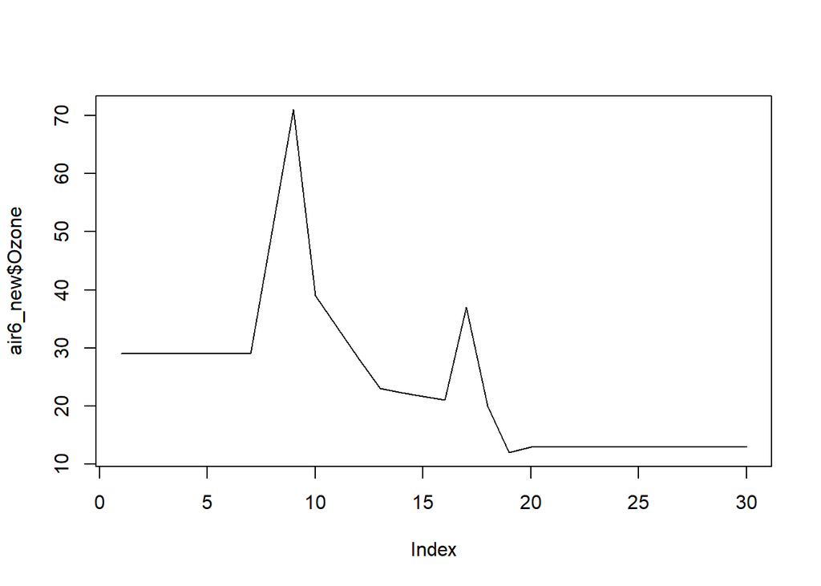

```r
plot(air6_new$Ozone,type="l")
```

이상치 파악하기 - 상자그림을 이용한 이상치 확인

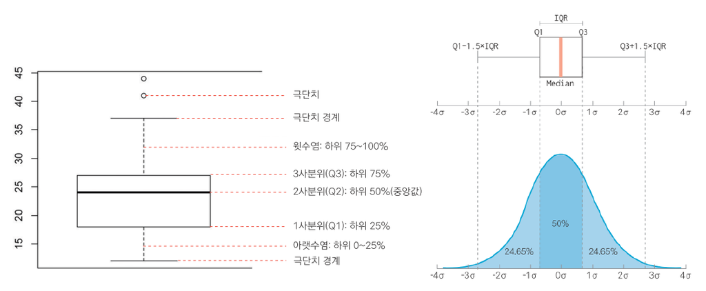

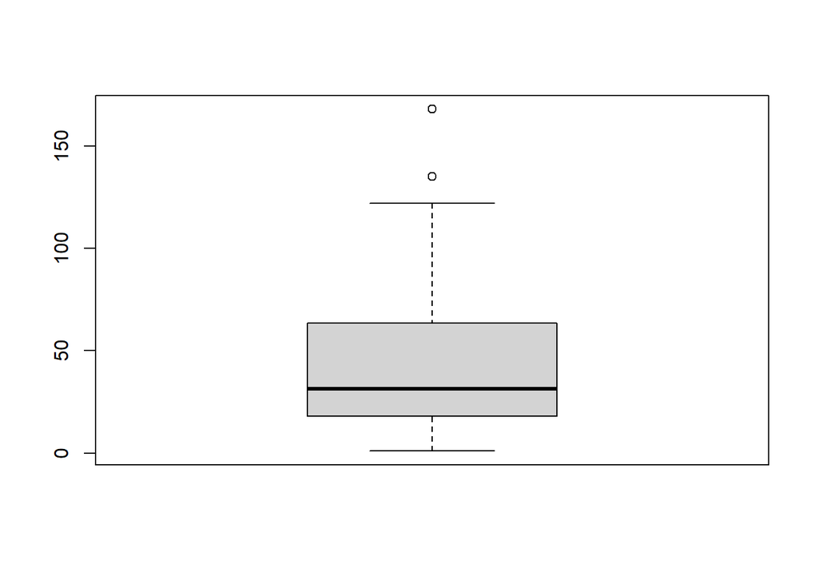

```r
p = boxplot(air$Ozone)
```

```r
p
```

```
## $stats
##       [,1]
## [1,]   1.0
## [2,]  18.0
## [3,]  31.5
## [4,]  63.5
## [5,] 122.0
##
## $n
## [1] 116
##
## $conf
##          [,1]
## [1,] 24.82518
## [2,] 38.17482
##
## $out
## [1] 135 168
##
## $group
## [1] 1 1
##
## $names
## [1] "1"
```

```r
p$out
```

```
## [1] 135 168
```

```r
air[air$Ozone %in% p$out,]
```

```
##     Ozone Solar.R Wind Temp Month Day
## 62    135     269  4.1   84     7   1
## 117   168     238  3.4   81     8  25
```

```r
air2=air
air2[air2$Ozone %in% p$out,"Ozone"]=NA
air2[c(62,117),]
```

```
##     Ozone Solar.R Wind Temp Month Day
## 62     NA     269  4.1   84     7   1
## 117    NA     238  3.4   81     8  25
```

```r
air2=air
air2[air2$Ozone %in% p$out,"Ozone"]=max(air2[!air2$Ozone %in% p$out,"Ozone"],na.rm=T)
air2[c(62,117),]
```

```
##     Ozone Solar.R Wind Temp Month Day
## 62    122     269  4.1   84     7   1
## 117   122     238  3.4   81     8  25
```

## **파생변수 생성**

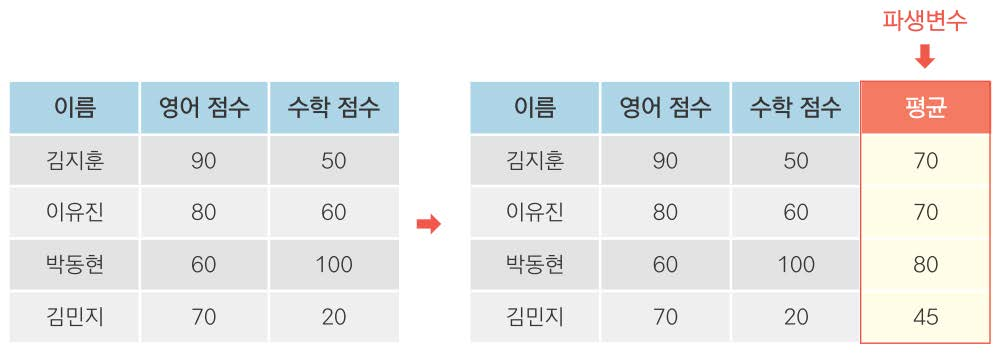

```r
df <- data.frame(var1 = c(4, 3, 8), var2 = c(2, 6, 1))
df
```

```
##   var1 var2
## 1    4    2
## 2    3    6
## 3    8    1
```

```r
df$var_sum <- df$var1 + df$var2 # var_sum 파생변수 생성
df
```

```
##   var1 var2 var_sum
## 1    4    2       6
## 2    3    6       9
## 3    8    1       9
```

```r
df$var_mean <- (df$var1 + df$var2)/2 # var_mean 파생변수 생성
df
```

```
##   var1 var2 var_sum var_mean
## 1    4    2       6      3.0
## 2    3    6       9      4.5
## 3    8    1       9      4.5
```

```r
if(!require(ggplot2)) install.packages("ggplot2")
library(ggplot2)
head(mpg)
```

```
## # A tibble: 6 × 11
##   manufacturer model displ  year   cyl trans      drv     cty   hwy fl    class
##   <chr>        <chr> <dbl> <int> <int> <chr>      <chr> <int> <int> <chr> <chr>
## 1 audi         a4      1.8  1999     4 auto(l5)   f        18    29 p     compa…
## 2 audi         a4      1.8  1999     4 manual(m5) f        21    29 p     compa…
## 3 audi         a4      2    2008     4 manual(m6) f        20    31 p     compa…
## 4 audi         a4      2    2008     4 auto(av)   f        21    30 p     compa…
## 5 audi         a4      2.8  1999     6 auto(l5)   f        16    26 p     compa…
## 6 audi         a4      2.8  1999     6 manual(m5) f        18    26 p     compa…
```

```r
mpg$total <- (mpg$cty + mpg$hwy)/2 # 통합 연비 변수 생성
mean(mpg$total)
```

```
## [1] 20.14957
```

```r
summary(mpg$total)
```

```
##    Min. 1st Qu.  Median    Mean 3rd Qu.    Max.
##   10.50   15.50   20.50   20.15   23.50   39.50
```

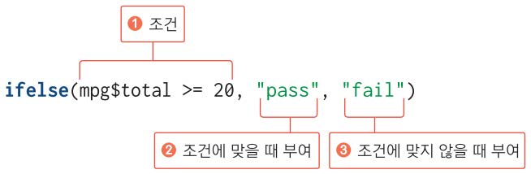

```r
# 20 이상이면 pass, 그렇지 않으면 fail 부여
mpg$test <- ifelse(mpg$total >= 20, "pass", "fail")
#head(mpg, 20)
table(mpg$test)
```

```
##
## fail pass
##  106  128
```

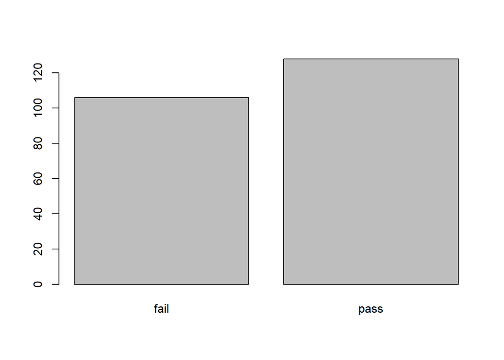

```r
barplot(table(mpg$test))
```

등급 기준이 3개 이상 A : 30 이상, B : 20~29, C : 20 미만

```r
# 20 이상이면 pass, 그렇지 않으면 fail 부여
mpg$grade <- ifelse(mpg$total >= 30, "A",
                    ifelse(mpg$total >= 20, "B", "C"))
#head(mpg, 20)
table(mpg$grade)
```

```
##
##   A   B   C
##  10 118 106
```

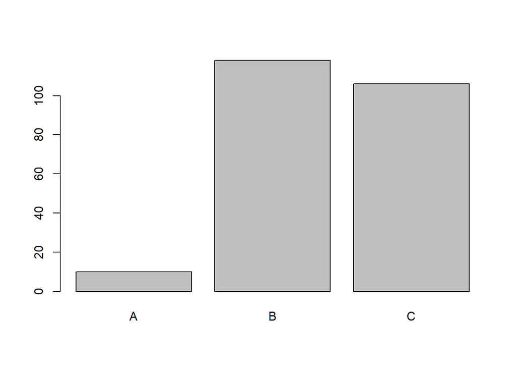

```r
barplot(table(mpg$grade))
```

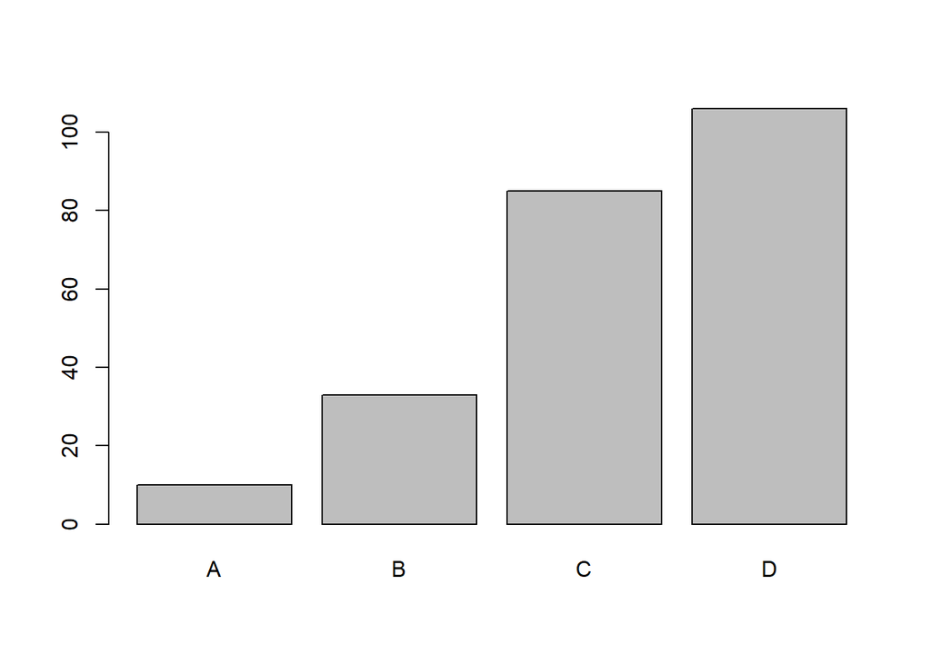

```r
mpg$grade2 <- ifelse(mpg$total >= 30, "A",
                     ifelse(mpg$total >= 25, "B", ifelse(mpg$total >= 20, "C", "D")))
barplot(table(mpg$grade2))
```

### 데이터의 유형

```r
a = 1000
str(a)
aa = as.character(a)
str(aa)

b = "5000"
a+b
bb = as.numeric(b)
a+bb

c = "1,000"
cc = as.numeric(c)

c2=gsub(",","",c)
cc=as.numeric(c2)
a+cc

e = "2020-10-10"
Sys.Date()-e
Sys.Date()-as.Date(e)

data <- read_excel("excel_exam.xlsx")
str(data)
head(data)
data2 = as.data.frame(data)
str(data2)
head(data2)
```

### 분석 연습하기

airquality 자료를 이용하여

1. Ozone이 가장 높은 수치를 보인 월은?
2. 1번에서 도출된 월의 평균온도는?
3. 일사량을 결측치 보간 하세요.
4. 결측치가 있는 관측치를 모두 제거한다면 풍속의 평균은?
5. 월 평균온도를 구하세요.
6. 월마다 가장 높은 온도가 측정된 일을 구하세요.